# Homework 3 Solutions

Matt Lukac

October 25, 2018

## Identifying Variables

In this study, we examine the effects a diet of enriched shrimp nauplii has on the size of zebrafish. We take the size to be defined in terms of the weight and standard length (SL) of the zebrafish. Let’s take a peak at the data.

```r
library(tidyverse)

#read in file
zfish <- read_tsv(file = "zfish_diet_IA.tsv")
#fix transcription errors
zfish$SL[which.max(zfish$SL)] <- zfish$SL[which.max(zfish$SL)]/10
zfish$Weight[which.max(zfish$Weight)] <- zfish$Weight[which.max(zfish$Weight)]/10
head(zfish)
```

```
## # A tibble: 6 x 4
##   Individual Diet        SL Weight
##        <int> <chr>    <dbl>  <dbl>
## 1          1 Control   3.58  0.554
## 2          2 Enriched  4.66  0.699
## 3          3 Enriched  4.5   0.644
## 4          4 Control   3.71  0.624
## 5          5 Control   4.36  0.688
## 6          6 Control   3.89  0.613
```

It looks like we have one categorical predictor variable, given by the diet, which is either `Control` or `Enriched`. We have two continuous response variables: standard length, and wet weight.

## Regression Significance Tests

Here, we’ll take a look at how closely the length is correlated to the weight. We should expect there to be a positive correlation since a longer body will weigh more than a shorter body of the same girth. Note the distinction of points from separate diets.

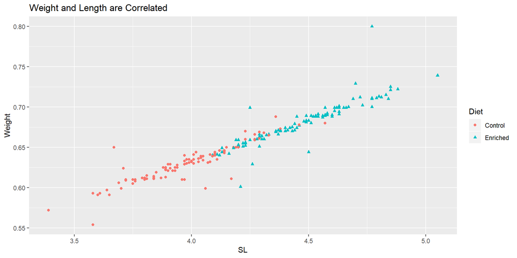

```r
library(ggplot2)
ggplot(data = zfish) +
  geom_point(mapping = aes(x = SL, y = Weight, color = Diet, shape = Diet), show.legend = T) +
  ggtitle("Weight and Length are Correlated")
```

As expected, the two response variables have a strong positive correlation. But let’s formalize this with a simple linear model. For the $i$th fish, let $y_i$ be the length of the fish and let $x_i$ be the wet weight of the fish. We will attempt to model the linear relationship of the two variables with
$$y_i = \beta_0 + \beta_1 x_i + \varepsilon_i$$
What’s more, we perform significance tests on the parameters $\beta_0$ and $\beta_1$ with null hypotheses
$$\begin{align}
H_0 &\colon \beta_0 = 0 \\
H_0 &\colon \beta_1 = 0
\end{align}$$
and alternative hypotheses
$$\begin{align}
H_1 &\colon \beta_0 \neq 0 \\
H_1 &\colon \beta_1 \neq 0
\end{align}$$

Now let’s perform the aforementioned significance tests with the `lm` function.

```r
zfish_lm <- lm(SL~Weight, data = zfish)
summary(zfish_lm)
```

```
##
## Call:
## lm(formula = SL ~ Weight, data = zfish)
##
## Residuals:
##      Min       1Q   Median       3Q      Max
## -0.70248 -0.03571  0.00388  0.03886  0.45093
##
## Coefficients:
##             Estimate Std. Error t value Pr(>|t|)
## (Intercept)  -1.4156     0.1386  -10.21   <2e-16 ***
## Weight        8.6101     0.2112   40.77   <2e-16 ***
## ---
## Signif. codes:  0 '***' 0.001 '**' 0.01 '*' 0.05 '.' 0.1 ' ' 1
##
## Residual standard error: 0.106 on 198 degrees of freedom
## Multiple R-squared:  0.8936, Adjusted R-squared:  0.893
## F-statistic:  1662 on 1 and 198 DF,  p-value: < 2.2e-16
```

## Residual Analysis

For us to trust conclusions drawn from these tests, we must meet the parametric assumptions needed for a simple linear model. That is, we must check the residuals $\varepsilon_i$ are approximately normal with mean 0, and that they have an approximately constant variance along the trendline. Let’s look at a plot of residuals against the fitted values.

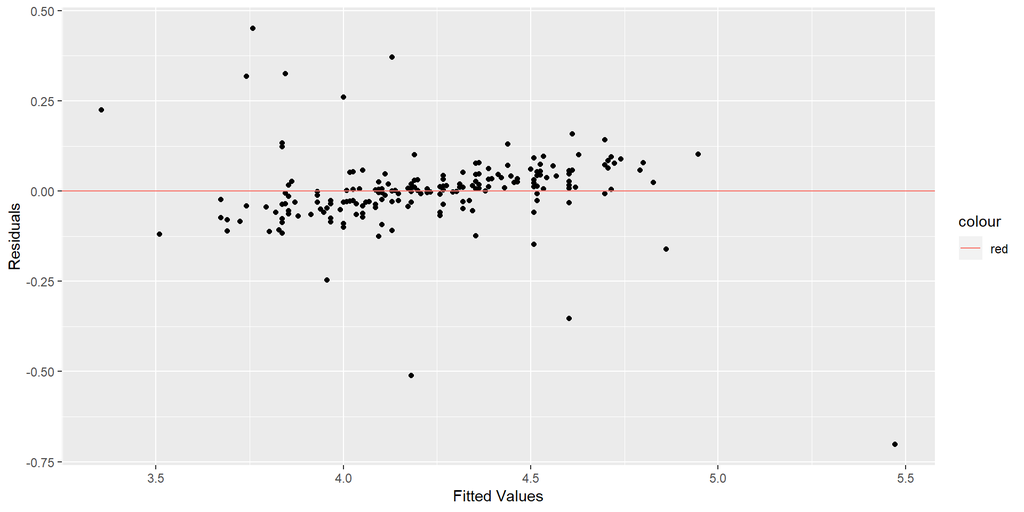

```r
ggplot() +
  geom_point(aes(x = zfish_lm$fitted.values, y = zfish_lm$residuals)) +
  geom_hline(aes(yintercept = 0, colour = 'red')) +
  xlab("Fitted Values") +
  ylab("Residuals")
```

It’s hard to just eyeball the homoscedasticity of the residuals. To measure this, we will order the 200 zebrafish with respect to the fitted values, break them into 10 bins of size 20 and compute the variance of each bin. The closer the variance of these variances is to 0, the more homoscedastic the residuals will be.

```r
df <- data.frame(zfish_lm$fitted.values, zfish_lm$residuals)
names(df) <- c("fitted_values", "residuals")
df <- df[order(df$fitted_values),]

#compute variance of ordered residuals from bins of size 20
resid_var <- NULL
n <- 1
while(n < length(df$residuals)){
  resid_var[ceiling(n/20)] <- var(df$residuals[n:(n+19)])
  n <- n+20
}
print(resid_var)
```

```
##  [1] 0.0259832087 0.0097783081 0.0060537788 0.0019101221 0.0223793260
##  [6] 0.0007691919 0.0023703356 0.0030457593 0.0084352927 0.0333534936
```

Indeed, the variance of these variances is 1.3440e-04, which is small enough to assert homoscedasticity of the residuals. They also appear to be approximately normal, from the below histogram.

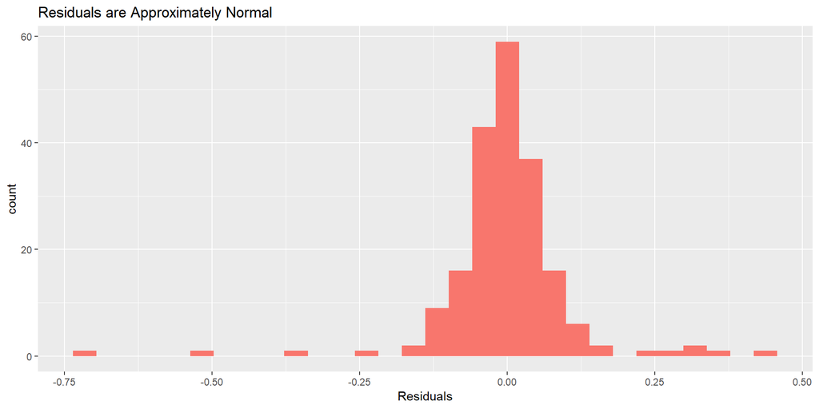

```r
ggplot() +
  geom_histogram(aes(zfish_lm$residuals, fill = 'red'), show.legend = F) +
  xlab("Residuals") +
  ggtitle("Residuals are Approximately Normal")
```

## Conclusions

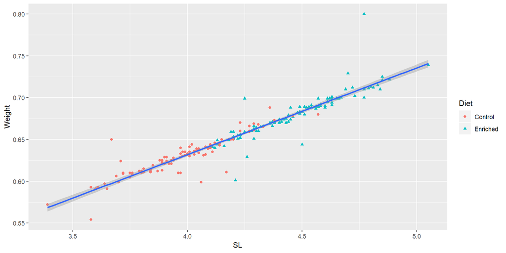

```r
ggplot(data = zfish) +
  geom_point(mapping = aes(x = SL, y = Weight, color = Diet, shape = Diet), show.legend = T) +
  geom_smooth(mapping = aes(x = SL, y = Weight), method = 'lm')
```

As we can see from the above test results, the significance test on $\beta_0$ returns a t-value of -10.21, giving a p-value of 6.17e-20. Similarly, the test on $\beta_1$ returns a t-value of 40.77, yielding a p-value of 2.88e-98. For both tests we reject the null hypothesis in favor of the alternative. What’s more, the F-statistic for the model is 1662.26, leading us to conclude this model is a better fit than a reduced model. Indeed, this was to be expected from the results of the significance test on $\beta_1$. In any case, the data support the claim that there is indeed a correlation between length and weight.